# Appendix

Eric Marcon, Florence Puech

21 March 2021

This document contains the code used to produce the figures of the paper and run all examples. It is part of an RStudio project with R Markdown documents.

# Preparing data

## Download data

Data are available on https://opendata.paris.fr/explore/dataset/les-arbres/export/

Preparing data consists of downloading open-data files and wrangling it to obtain:

- `the_trees`: a tibble with one line per tree, described mainly by its species, coordinates, and the green space it belongs to.
- `Paris`: an `owin` object, i.e. a geometric window with the limits of the city.

Those files are cached in the `data` folder. The wrangling process can be reinitialized by deleting it, e.g. to benefit from an update of the original data files.

```r
# Create the data folder if necessary
if (!dir.exists("data")) dir.create("data")
# Download the dataset if necessary (100)
if (!file.exists("data/ParisTrees.RData"))
  download.file(
    "https://opendata.paris.fr/explore/dataset/les-arbres/download/?format=geojson",
    destfile="data/les-arbres.geojson")
```

Another dataset contains the limits of arrondissements, i.e. Paris administrative sectors.

```r
# Arrondissements
if (!file.exists("data/ParisTrees.RData"))
  download.file(
    "https://opendata.arcgis.com/datasets/8463ae61c7ba4388bf08189effcbf2f1_0.geojson",
    destfile="data/arrondissements.geojson")
```

## Datum

GeoJSON datasets are read by the **rgdal** package.

```r
if (!file.exists("data/ParisTrees.RData")) {
  library("rgdal")
  the_trees_GeoJSON <- readOGR("data/les-arbres.geojson",
                             layer = "les-arbres",
                             encoding = "UTF-8", use_iconv = TRUE)
  arrondissements <- readOGR("data/arrondissements.geojson",
                           layer="COMMUNE_ARRONDISSEMENT_BOIS",
                           encoding = "UTF-8", use_iconv = TRUE)
}
```

Data are projected into Lambert 93 coordinates.

```r
if (!file.exists("data/ParisTrees.RData")) {
  library("magrittr")
  the_trees_GeoJSON %<>%
    spTransform(CRS("+init=epsg:2154"))
  arrondissements %<>%
    spTransform(CRS("+init=epsg:2154"))
}
```

Latitude and longitude are now in meters.

## The trees

Useful data are gathered in a tibble to simplify further operations. Column names are translated into English. So are green-space types.

```r
if (!file.exists("data/ParisTrees.RData")) {
  library("dplyr")
  library("stringr")
  library("forcats")
  the_trees_GeoJSON@data %>%
    as_tibble() %>%
    # Bind Lambert coordinates
    bind_cols(as.data.frame(the_trees_GeoJSON@coords)) %>%
    # Delete useless columns
    select(-idemplacement, -typeemplacement, -geo_point_2d1, -geo_point_2d2,
           -complementadresse, -stadedeveloppement) %>%
    # Retain intra-muros Paris data only
    dplyr::filter(str_detect(arrondissement, "^PARIS")) %>%
    # Add a full species name column
    mutate(SpeciesName=as.factor(paste(genre, espece))) %>%
    # Factorize some columns
    mutate(libellefrancais=as.factor(libellefrancais)) %>%
    mutate(genre=as.factor(genre)) %>%
    mutate(espece=as.factor(espece)) %>%
    mutate(remarquable=(remarquable=="OUI")) %>%
    # Translate green space types
    mutate(domanialite=as.factor(domanialite)) %>%
    mutate(domanialite=fct_recode(domanialite,
             "Street" = "Alignement",
             "Park" = "Jardin",
             "Cemetery" = "CIMETIERE",
             "School" = "DASCO",
             "Ring Motorway" = "PERIPHERIQUE",
             "Sports facility" = "DJS",
             "Nursery" = "DFPE",
             "Cultural facility" = "DAC",
             "Social Services" = "DASES")) %>%
    # Arrondissement reduced to a number
    mutate(arrondissement=str_replace(arrondissement, "PARIS ", "")) %>%
    mutate(arrondissement=str_replace(arrondissement, "E ARRDT", "")) %>%
    mutate(arrondissement=str_replace(arrondissement, "ER ARRDT", "")) %>%
    mutate(arrondissement=as.integer(arrondissement)) %>%
    # Simplify cemetery addresses to have a single one per cemetery
    mutate(adresse=str_trim(ifelse(str_detect(as.character(adresse), "^CIMETIERE "),
      str_split(as.character(adresse), "/", simplify=TRUE)[, 1],
      as.character(adresse)))) %>%
    # Avoid duplicate addresses by adding arrondissement and domanialite data to them
    mutate(adresse = as.factor(paste(adresse, arrondissement, domanialite))) %>%
    # Rename columns
    rename(ID=idbase,
           FrenchSpeciesName=libellefrancais,
           GreenSpaceType=domanialite,
           Address=adresse,
           Arrondissement=arrondissement,
           Circumference=circonferenceencm,
           Height=hauteurenm,
           Remarkable=remarquable,
           Genus=genre,
           Species=espece,
           x=coords.x1,
           y=coords.x2,
           VarietyOrCultivar=varieteoucultivar) %>%
    # Reorder them
    select(ID, SpeciesName, FrenchSpeciesName, GreenSpaceType, Address, Arrondissement,
           Circumference, Height, Remarkable, Genus, Species, x, y,
           VarietyOrCultivar) ->
    the_trees
}
```

## Arrondissements

```r
if (!file.exists("data/ParisTrees.RData")) {
  # Retain intra-muros Paris data only (postal code = 75xxx). Eliminate outer forests ("Bois")
  arrondissements <- arrondissements[arrondissements@data$C_CAINSEE %/% 1000 == 75 &
                                       arrondissements@data$B_BOIS == "N" , ]
  arrondissements <- arrondissements[arrondissements@data$C_CAINSEE %/% 1000 == 75 &
                                       arrondissements@data$B_BOIS == "N" , ]
  # Reduce arrondissement name to its number
  arrondissements@data$L_CAB %<>%
    str_replace("er", "") %>%
    str_replace("e", "") %>%
    str_replace("ème", "") %>%
    as.integer()
  # Dissolve arrondissement borders to get a single polygon for Paris
  library("maptools")
  Paris <- unionSpatialPolygons(arrondissements,
                                rep(TRUE, length(arrondissements@polygons)))
}
```

## Save the data

```r
if (!file.exists("data/ParisTrees.RData"))
  save(the_trees, Paris, file = "data/ParisTrees.RData")
```

# Exploratory analyzes

```r
# Load the data
load("data/ParisTrees.RData")
```

## Species abundances

The total number of trees is 164070.

The most abundant species are:

```r
library("dplyr")
the_trees %>%
  group_by(SpeciesName) %>%
  summarise(Number=n(), .groups='drop') %>%
  arrange(desc(Number))%>%
  knitr::kable(caption="Domanialité", longtable = FALSE, booktabs = TRUE) %>%
  kableExtra::kable_styling(bootstrap_options = "striped", full_width = FALSE)
```

Domanialité

| SpeciesName | Number |
| --- | --- |
| Platanus x hispanica | 33360 |
| Aesculus hippocastanum | 15466 |
| Sophora japonica | 10674 |
| Tilia tomentosa | 7006 |
| Acer platanoides | 4421 |
| Acer pseudoplatanus | 4347 |
| Aesculus x carnea | 3954 |
| Celtis australis | 3595 |
| Tilia x europaea | 3561 |
| Platanus occidentalis | 3192 |
| Pyrus calleryana | 2980 |
| Tilia cordata | 2695 |
| Carpinus betulus | 2520 |
| Fraxinus excelsior | 2418 |
| Corylus colurna | 2155 |
| Prunus serrulata | 2022 |
| Robinia pseudoacacia | 1992 |
| Taxus baccata | 1765 |
| Tilia n. sp. | 1703 |
| Pinus nigra | 1500 |
| Tilia platyphyllos | 1411 |
| Fagus sylvatica | 1372 |
| Paulownia tomentosa | 1334 |
| Acer campestre | 1221 |
| Betula pendula | 1105 |
| Pinus nigra subsp. nigra | 1083 |
| Malus domestica | 1031 |
| Cercis siliquastrum | 962 |
| Ulmus NA | 961 |
| Ginkgo biloba | 956 |

[output cut: 622 more lines]

# Spatial concentration

## Weighted, Marked, Planar Point Pattern

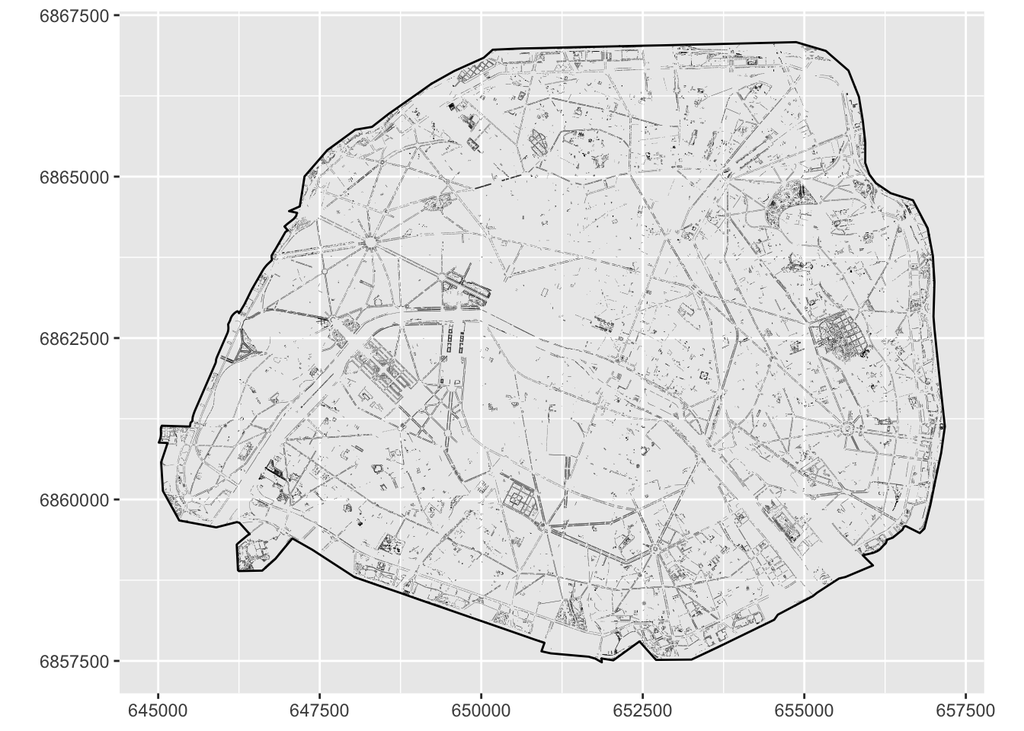

```r
# Prepare the window
library("maptools")
library("dbmss")
Paris_owin <- as.owin(Paris)
# Make a wmppp object
the_trees %>%
  select(x, y, SpeciesName) %>%
  rename(PointType = SpeciesName) %>%
  as.wmppp(window = Paris_owin) ->
  the_trees_wmppp
# Plot the map without the too-many trees (alpha=0)
autoplot(the_trees_wmppp, alpha = 0) +
  # Add the trees as small black points
  geom_point(aes(x = x, y = y), size = 0.1, stroke = 0) +
  # Hide the legend
  guides(color = FALSE, size = FALSE)
```

## Concentration

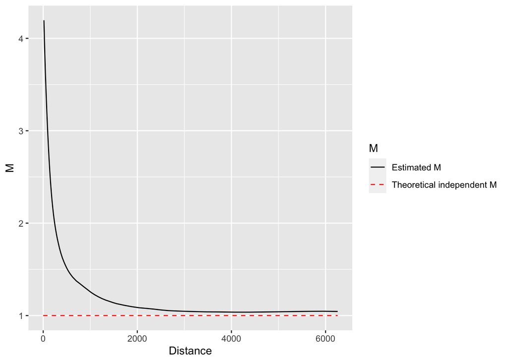

```r
M_Platanus <- Mhat(the_trees_wmppp, ReferenceType = "Platanus x hispanica")
autoplot(M_Platanus)
```

# Diversity

In entropart, data are organized in metacommunity object where each line is a species and each column a community (here, a street).

```r
library("tidyr")
library("entropart")
the_trees %>%
  # Retain the streets
  dplyr::filter(GreenSpaceType == "Street") %>%
  select(SpeciesName, Address, ID)  %>%
  pivot_wider(names_from = Address,
            values_from = ID,
            values_fill = 0,
            values_fn = length) %>%
  MetaCommunity(Weights = colSums(.[, -1])) %>%
  # Suppress warnings due to sample coverage estimation
  suppressWarnings -> streets_MC
```

Diversity of the streets :

```r
DivPart(q = 1, streets_MC) -> streets_diversity
streets_diversity$TotalAlphaDiversity
```

```
## [1] 1.892585
```

```r
streets_diversity$TotalBetaDiversity
```

```
##    None
## 11.8056
```

```r
streets_diversity$GammaDiversity
```

```
##    None
## 22.3431
```

# Spatially explicit diversity

## Make a point pattern (wmppp) from its address

```r
#' wmppp from an address
#'
#' @param green_spaces A dataframe with address, x and y columns
#' @param address An address to be found in `green_spaces$address`
#' @param unitname A vector with the name of the unit of distance (singular, plural)
#'
#' @return A `wmppp` object
wmppp_address <- function(green_spaces, address, unitname = c("meter", "meters")) {
  # Prepare the dataframe
  green_spaces %>%
    dplyr::filter(Address == address) %>%
    dplyr::select(x, y,
           PointType=SpeciesName,
           PointWeight=Circumference) %>%
    dbmss::wmppp(unitname = unitname)
}
```

## Parc des Buttes Chaumont

```r
Buttes_Chaumont <- wmppp_address(the_trees, "PARC DES BUTTES CHAUMONT 19 Park")
```

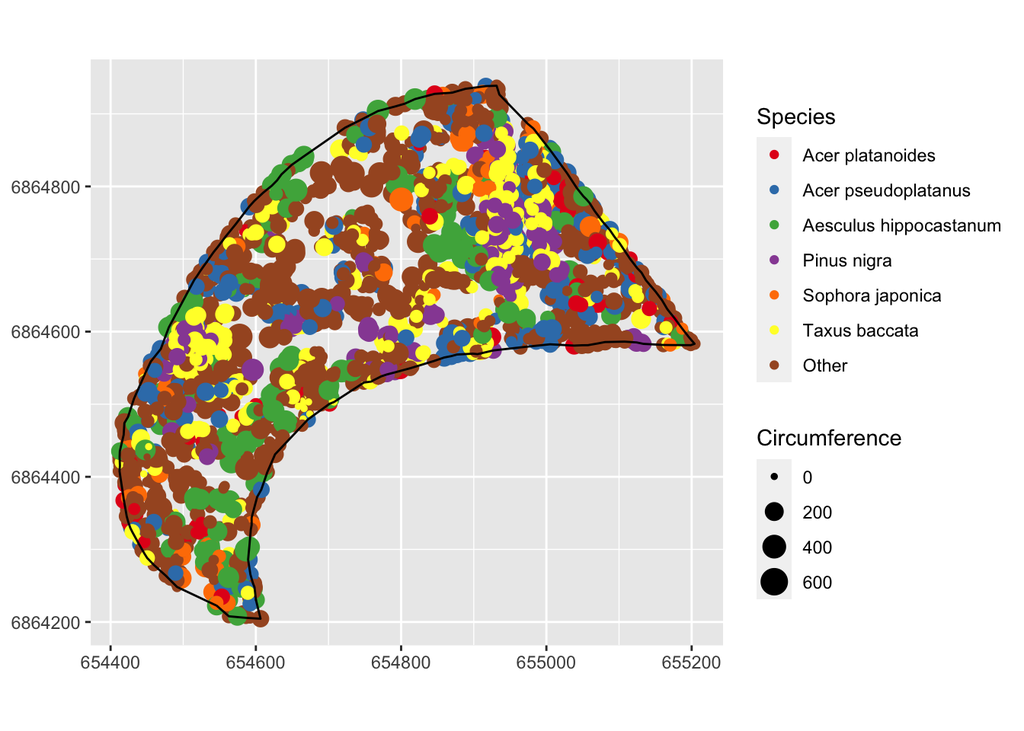

```r
library("SpatDiv")
Buttes_Chaumont$window <- alphahull(Buttes_Chaumont)
autoplot(Buttes_Chaumont, labelSize = "Circumference", labelColor = "Species")
```

## Local diversity

```r
Buttes_Chaumont_accum <- Mixing(Buttes_Chaumont, q.seq=c(0,1), n.seq = c(5, 10),  Individual=TRUE)
```

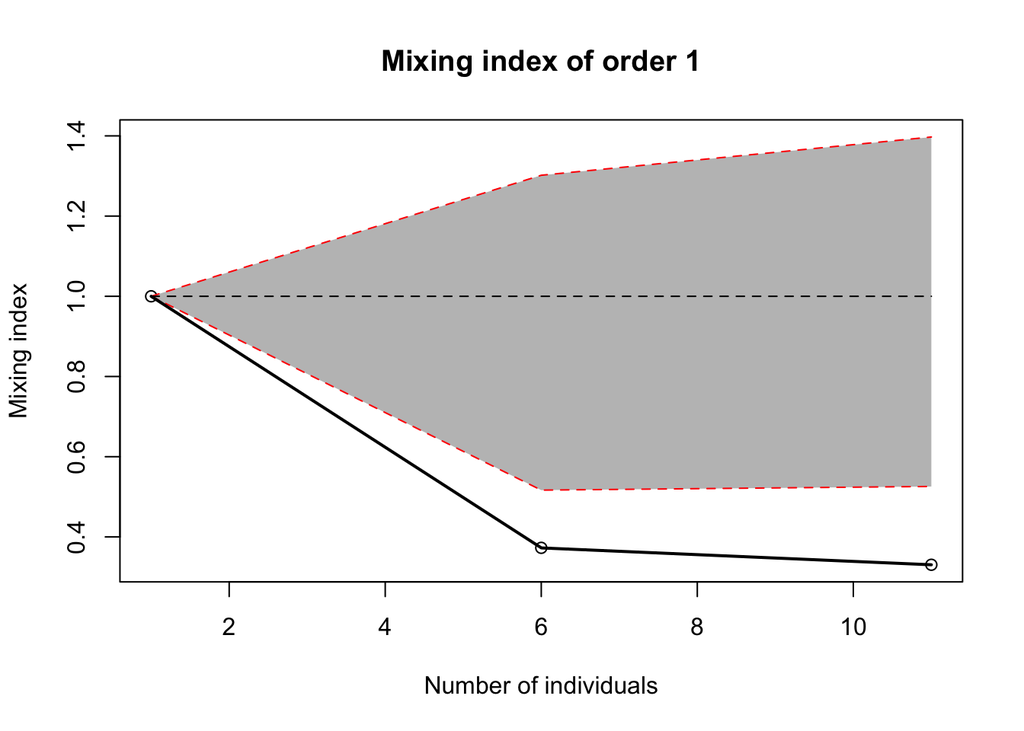

```r
plot(Buttes_Chaumont_accum, q=1)
```

```
## [using ordinary kriging]
```

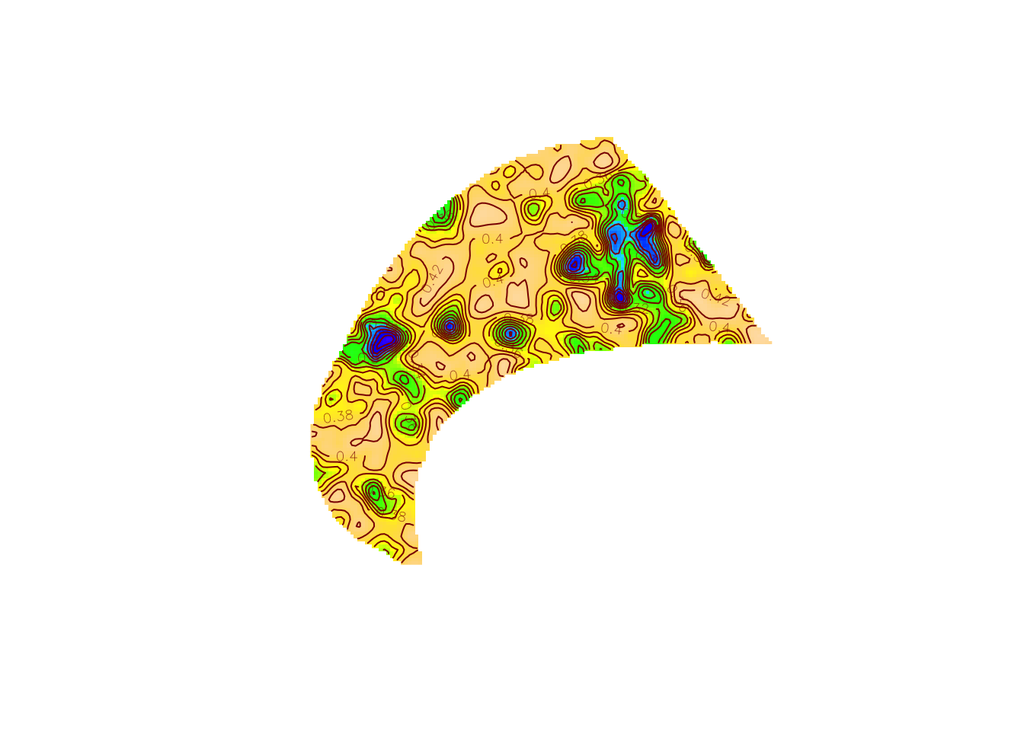

```r
MapPlot(Buttes_Chaumont_accum, Order=1, NeighborHood=11)
```